# **(Not) Merely Symbolic:** Reactions to Radical Right Success

EPSS 2026, Belfast

Frederik  
Thieme

frederik.thieme@hu-berlin.de

Humboldt-Universität zu Berlin

June 17, 2026

## RRPs in Europe: from representation to power 📈

# Why are we not seeing widespread countermobilization against radical right success?

## Preview ⏩️

- **Question**: Why are we not seeing widespread `countermobilization` against radical right success?
- **Argument**: drawing on intergroup threat theory
  - `symbolically` threatened groups not concerned
  - `realistically` threatened groups show pragmatic electoral responses and protest mobilization
- **Empirical Strategy**:
  - `Descriptive:` open-ended most-important-problem responses
  - `Electoral Effects`: Staggered DiD around concern-onset
- **Results**:
  - preliminary analysis confirms `pragmatic electoral response`aimed to curb RRP success

## Theory

- Intergroup Threat Theory (Stephan, Ybarra, and Morrison 2009):
  - `symbolic` threat: to values, beliefs, identity
  - `realistic` threat to resources, power, physical wellbeing
  - subjective perceptions matter, not objective conditions

$\rightarrow$ Symbolic threat triggers `distinction`, realistic threat triggers `pragmatic responses`

**Argument**:

- symbolic threat of RRP governance is `universal`
- realistic threat is `unequally distributed`

## Who faces realistic threat?

- `migrant (background) communities`
  - key out-group within radical right politics
  - to face policy and everyday discrimination, exclusion and potentially violence
- `young women`
  - sexism and anti-feminist backlash important dimensions of RRP success
  - young women navigate (higher) education, labor market integration, and …
  - family formation, which concerns sexual self-determination and reproductive rights

## Expected Pragmatic Responses

- `Strategic voting`
  - support for established parliamentary parties to ensure impact in seat allocation
  - strategic compromise in tight SMD races
- `Overshooting` to the left
  - perception of right-tilt leads to overcompensation to the left, even if not fully aligned with preferences
  - across the ideological spectrum
- `Protest mobilization`
  - non-electoral mobilization to signal opposition and empower ingroup

## Who is concerned about the radical right? (1/3)

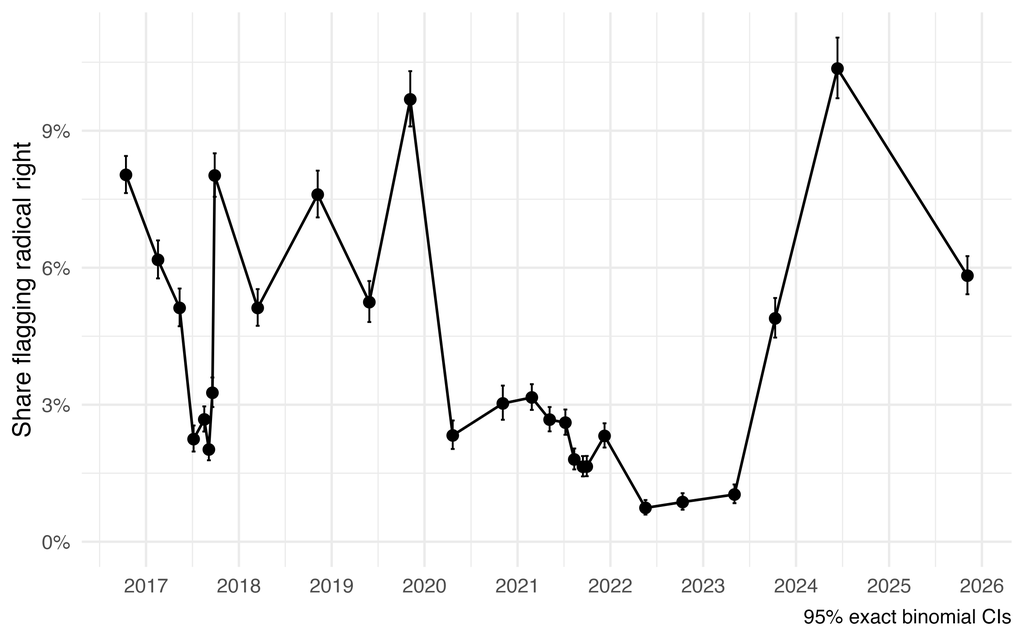

## Who is concerned about the radical right? (2/3)

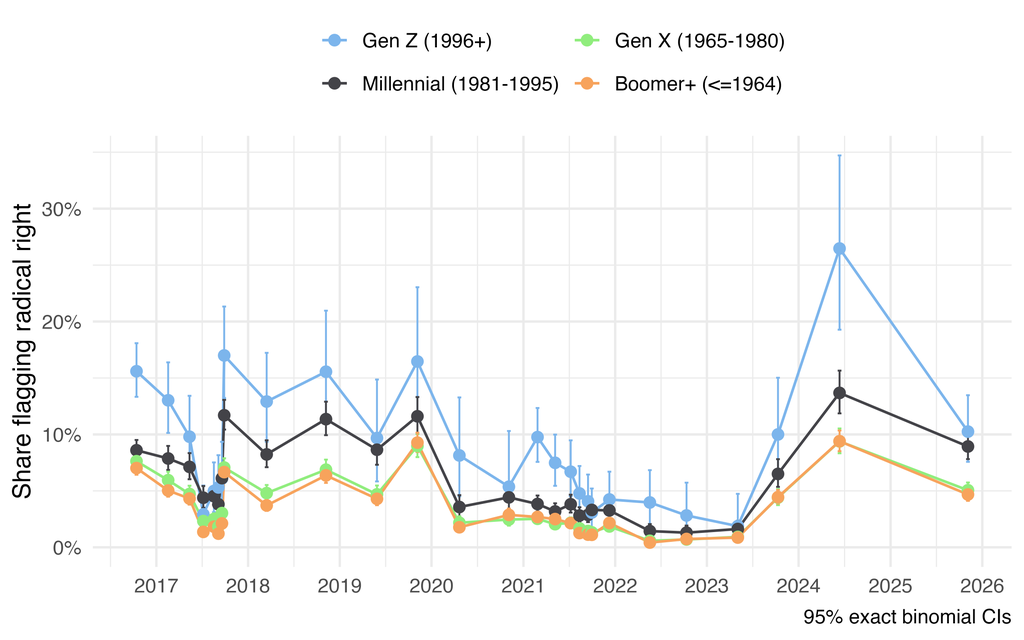

## Who is concerned about the radical right? (3/3)

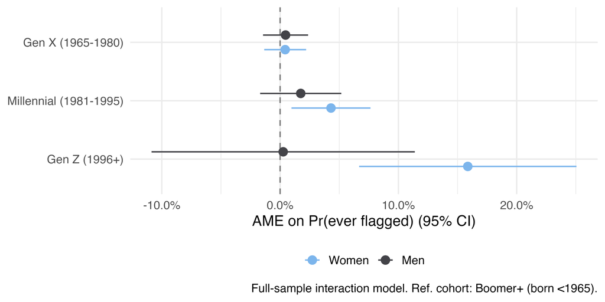

## Electoral effects of concern for the radical right (1/2)

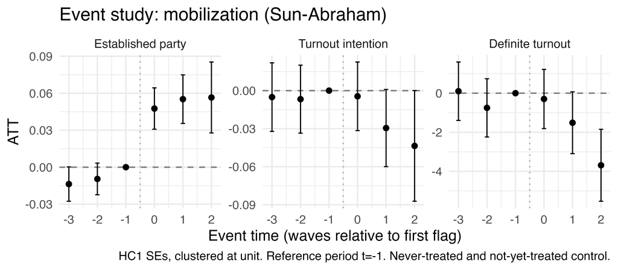

## Electoral effects of concern for the radical right (2/2)

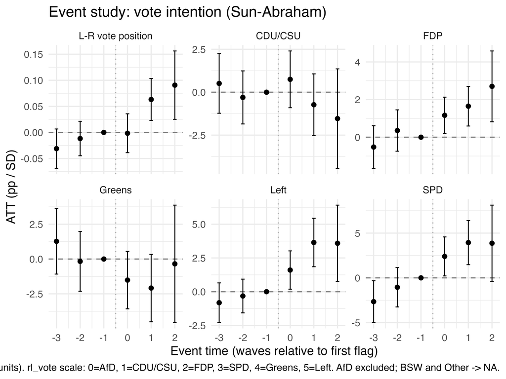

## Next Steps

- incorporate `LGBTQIA+` community into theory? what about *homonationalism*?
- migrant (background) communities `underrepresented` in the current data
- extend `outcome scope` to all theoretically relevant behaviors, particularly protest mobilization

## Conclusion & Contribution

- Reactions to RRP success are shaped by `threat perceptions`, which are unequally distributed
- `Concerned voters` show pragmatic electoral responses
  - support for parliamentary parties, overshooting to the left

**Contribution:**

- extends supporter-focused RRP research (Valentim 2024, 2021)
- beyond entry into parliament as point of observation (Bischof and Wagner 2019; Castanho Silva 2018)
- speaks to broader debates on role of sexism and gender gaps within RRP politics (Milosav et al. 2025; Anduiza and Rico 2024)

# Thank you for your attention.

Questions or feedback? Hit me up:

- 🌐 [frederikthieme.net](https://frederikthieme.net/)
- 📥 frederik.thieme@hu-berlin.de
- 🟦 frederikthieme.bsky.social

# Literature

Anduiza, Eva, and Guillem Rico. 2024. “Sexism and the Far-Right Vote: The Individual Dynamics of Gender Backlash.” *American Journal of Political Science* 68 (2): 478–93. https://doi.org/10.1111/ajps.12759.

Bischof, Daniel, and Markus Wagner. 2019. “Do Voters Polarize When Radical Parties Enter Parliament?” *American Journal of Political Science* 63 (4): 888–904. https://doi.org/10.1111/ajps.12449.

Castanho Silva, Bruno. 2018. “Populist Radical Right Parties and Mass Polarization in the Netherlands.” *European Political Science Review* 10 (2): 219–44. https://doi.org/10.1017/S1755773917000066.

Milosav, Ðorđe, Zachary Dickson, Sara B. Hobolt, Heike Klüver, Theresa Kuhn, and Toni Rodon. 2025. “The Youth Gender Gap in Support for the Far Right.” *Journal of European Public Policy*, March, 1–25. https://doi.org/10.1080/13501763.2025.2481181.

Stephan, Walter G, Oscar Ybarra, and Kimberly Rios Morrison. 2009. “3 Intergroup Threat Theory.” *In: Handbook of Prejudice, Stereotyping, and Discrimination (Ed.: Nelson, Todd D.).*

Valentim, Vicente. 2021. “Parliamentary Representation and the Normalization of Radical Right Support.” *Comparative Political Studies* 54 (14): 2475–2511. https://doi.org/10.1177/0010414021997159.

———. 2024. *The Normalization of the Radical Right: A Norms Theory of Political Supply and Demand*. 1st ed. Oxford University PressOxford. https://doi.org/10.1093/9780198926740.001.0001.